# HR Attrition Prediction and Retention Strategy Using Machine Learning

Mena Melaku

2025-03-28

# 1 Introduction

This project builds a KNN model to predict whether an employee will leave or stay with their employer.

The dataset includes features such as satisfaction, workload, salary, and department.

The model outputs: - 0 = stayed - 1 = left

# 2 Step 1: Define the Problem

We are predicting whether an employee will leave.

Target variable: - `left` (1 = left, 0 = stayed)

This is a binary classification problem.

# 3 Step 2: Get and Clean the Data

Load the dataset and prepare it for modeling.

```r
hr <- read.csv("../data/hrdata.csv")
```

remove unnecessary columns

```r
hr$X <- NULL
```

```r
hr$dept <- hr$sales
hr$sales <- NULL
```

convert categorical variables to factors

```r
hr$salary <- as.factor(hr$salary)
hr$dept <- as.factor(hr$dept)
```

verify data structure

```r
str(hr)
```

```
## 'data.frame':    14999 obs. of  10 variables:
##  $ satisfaction_level   : num  0.38 0.8 0.11 0.72 0.37 0.41 0.1 0.92 0.89 0.42 ...
##  $ last_evaluation      : num  0.53 0.86 0.88 0.87 0.52 0.5 0.77 0.85 1 0.53 ...
##  $ number_project       : int  2 5 7 5 2 2 6 5 5 2 ...
##  $ average_montly_hours : int  157 262 272 223 159 153 247 259 224 142 ...
##  $ time_spend_company   : int  3 6 4 5 3 3 4 5 5 3 ...
##  $ Work_accident        : int  0 0 0 0 0 0 0 0 0 0 ...
##  $ left                 : int  1 1 1 1 1 1 1 1 1 1 ...
##  $ promotion_last_5years: int  0 0 0 0 0 0 0 0 0 0 ...
##  $ salary               : Factor w/ 3 levels "high","low","medium": 2 3 3 2 2 2 2 2 2 2 ...
##  $ dept                 : Factor w/ 10 levels "accounting","hr",..: 8 8 8 8 8 8 8 8 8 8 ...
```

View summary statistics

```r
summary(hr)
```

```
##  satisfaction_level last_evaluation  number_project  average_montly_hours
##  Min.   :0.0900     Min.   :0.3600   Min.   :2.000   Min.   : 96.0
##  1st Qu.:0.4400     1st Qu.:0.5600   1st Qu.:3.000   1st Qu.:156.0
##  Median :0.6400     Median :0.7200   Median :4.000   Median :200.0
##  Mean   :0.6128     Mean   :0.7161   Mean   :3.803   Mean   :201.1
##  3rd Qu.:0.8200     3rd Qu.:0.8700   3rd Qu.:5.000   3rd Qu.:245.0
##  Max.   :1.0000     Max.   :1.0000   Max.   :7.000   Max.   :310.0
##
##  time_spend_company Work_accident         left        promotion_last_5years
##  Min.   : 2.000     Min.   :0.0000   Min.   :0.0000   Min.   :0.00000
##  1st Qu.: 3.000     1st Qu.:0.0000   1st Qu.:0.0000   1st Qu.:0.00000
##  Median : 3.000     Median :0.0000   Median :0.0000   Median :0.00000
##  Mean   : 3.498     Mean   :0.1446   Mean   :0.2381   Mean   :0.02127
##  3rd Qu.: 4.000     3rd Qu.:0.0000   3rd Qu.:0.0000   3rd Qu.:0.00000
##  Max.   :10.000     Max.   :1.0000   Max.   :1.0000   Max.   :1.00000
##
##     salary              dept
##  high  :1237   sales      :4140
##  low   :7316   technical  :2720
##  medium:6446   support    :2229
##                IT         :1227
##                product_mng: 902
##                marketing  : 858
##                (Other)    :2923
```

```r
colSums(is.na(hr))
```

```
##    satisfaction_level       last_evaluation        number_project
##                     0                     0                     0
##  average_montly_hours    time_spend_company         Work_accident
##                     0                     0                     0
##                  left promotion_last_5years                salary
##                     0                     0                     0
##                  dept
##                     0
```

```r
summary(hr)
```

```
##  satisfaction_level last_evaluation  number_project  average_montly_hours
##  Min.   :0.0900     Min.   :0.3600   Min.   :2.000   Min.   : 96.0
##  1st Qu.:0.4400     1st Qu.:0.5600   1st Qu.:3.000   1st Qu.:156.0
##  Median :0.6400     Median :0.7200   Median :4.000   Median :200.0
##  Mean   :0.6128     Mean   :0.7161   Mean   :3.803   Mean   :201.1
##  3rd Qu.:0.8200     3rd Qu.:0.8700   3rd Qu.:5.000   3rd Qu.:245.0
##  Max.   :1.0000     Max.   :1.0000   Max.   :7.000   Max.   :310.0
##
##  time_spend_company Work_accident         left        promotion_last_5years
##  Min.   : 2.000     Min.   :0.0000   Min.   :0.0000   Min.   :0.00000
##  1st Qu.: 3.000     1st Qu.:0.0000   1st Qu.:0.0000   1st Qu.:0.00000
##  Median : 3.000     Median :0.0000   Median :0.0000   Median :0.00000
##  Mean   : 3.498     Mean   :0.1446   Mean   :0.2381   Mean   :0.02127
##  3rd Qu.: 4.000     3rd Qu.:0.0000   3rd Qu.:0.0000   3rd Qu.:0.00000
##  Max.   :10.000     Max.   :1.0000   Max.   :1.0000   Max.   :1.00000
##
##     salary              dept
##  high  :1237   sales      :4140
##  low   :7316   technical  :2720
##  medium:6446   support    :2229
##                IT         :1227
##                product_mng: 902
##                marketing  : 858
##                (Other)    :2923
```

**Step 3:** Encode categorical variables

```r
#model.matrix() creates dummy variables for factors
hr_dummies <- as.data.frame(model.matrix(~ . -1, data = hr))

# View the structure
str(hr_dummies)
```

```
## 'data.frame':    14999 obs. of  20 variables:
##  $ satisfaction_level   : num  0.38 0.8 0.11 0.72 0.37 0.41 0.1 0.92 0.89 0.42 ...
##  $ last_evaluation      : num  0.53 0.86 0.88 0.87 0.52 0.5 0.77 0.85 1 0.53 ...
##  $ number_project       : num  2 5 7 5 2 2 6 5 5 2 ...
##  $ average_montly_hours : num  157 262 272 223 159 153 247 259 224 142 ...
##  $ time_spend_company   : num  3 6 4 5 3 3 4 5 5 3 ...
##  $ Work_accident        : num  0 0 0 0 0 0 0 0 0 0 ...
##  $ left                 : num  1 1 1 1 1 1 1 1 1 1 ...
##  $ promotion_last_5years: num  0 0 0 0 0 0 0 0 0 0 ...
##  $ salaryhigh           : num  0 0 0 0 0 0 0 0 0 0 ...
##  $ salarylow            : num  1 0 0 1 1 1 1 1 1 1 ...
##  $ salarymedium         : num  0 1 1 0 0 0 0 0 0 0 ...
##  $ depthr               : num  0 0 0 0 0 0 0 0 0 0 ...
##  $ deptIT               : num  0 0 0 0 0 0 0 0 0 0 ...
##  $ deptmanagement       : num  0 0 0 0 0 0 0 0 0 0 ...
##  $ deptmarketing        : num  0 0 0 0 0 0 0 0 0 0 ...
##  $ deptproduct_mng      : num  0 0 0 0 0 0 0 0 0 0 ...
##  $ deptRandD            : num  0 0 0 0 0 0 0 0 0 0 ...
##  $ deptsales            : num  1 1 1 1 1 1 1 1 1 1 ...
##  $ deptsupport          : num  0 0 0 0 0 0 0 0 0 0 ...
##  $ depttechnical        : num  0 0 0 0 0 0 0 0 0 0 ...
```

Normalize all numeric values to range 0–1

```r
#Min-Max scaling function
minmax <- function(x) {
  (x - min(x)) / (max(x) - min(x))
}

#Apply to all columns
hr_norm <- as.data.frame(lapply(hr_dummies, minmax))

# View summary to confirm values are between 0 and 1
summary(hr_norm)
```

```
##  satisfaction_level last_evaluation  number_project   average_montly_hours
##  Min.   :0.0000     Min.   :0.0000   Min.   :0.0000   Min.   :0.0000
##  1st Qu.:0.3846     1st Qu.:0.3125   1st Qu.:0.2000   1st Qu.:0.2804
##  Median :0.6044     Median :0.5625   Median :0.4000   Median :0.4860
##  Mean   :0.5745     Mean   :0.5564   Mean   :0.3606   Mean   :0.4909
##  3rd Qu.:0.8022     3rd Qu.:0.7969   3rd Qu.:0.6000   3rd Qu.:0.6963
##  Max.   :1.0000     Max.   :1.0000   Max.   :1.0000   Max.   :1.0000
##  time_spend_company Work_accident         left        promotion_last_5years
##  Min.   :0.0000     Min.   :0.0000   Min.   :0.0000   Min.   :0.00000
##  1st Qu.:0.1250     1st Qu.:0.0000   1st Qu.:0.0000   1st Qu.:0.00000
##  Median :0.1250     Median :0.0000   Median :0.0000   Median :0.00000
##  Mean   :0.1873     Mean   :0.1446   Mean   :0.2381   Mean   :0.02127
##  3rd Qu.:0.2500     3rd Qu.:0.0000   3rd Qu.:0.0000   3rd Qu.:0.00000
##  Max.   :1.0000     Max.   :1.0000   Max.   :1.0000   Max.   :1.00000
##    salaryhigh        salarylow       salarymedium        depthr
##  Min.   :0.00000   Min.   :0.0000   Min.   :0.0000   Min.   :0.00000
##  1st Qu.:0.00000   1st Qu.:0.0000   1st Qu.:0.0000   1st Qu.:0.00000
##  Median :0.00000   Median :0.0000   Median :0.0000   Median :0.00000
##  Mean   :0.08247   Mean   :0.4878   Mean   :0.4298   Mean   :0.04927
##  3rd Qu.:0.00000   3rd Qu.:1.0000   3rd Qu.:1.0000   3rd Qu.:0.00000
##  Max.   :1.00000   Max.   :1.0000   Max.   :1.0000   Max.   :1.00000
##      deptIT        deptmanagement  deptmarketing    deptproduct_mng
##  Min.   :0.00000   Min.   :0.000   Min.   :0.0000   Min.   :0.00000
##  1st Qu.:0.00000   1st Qu.:0.000   1st Qu.:0.0000   1st Qu.:0.00000
##  Median :0.00000   Median :0.000   Median :0.0000   Median :0.00000
##  Mean   :0.08181   Mean   :0.042   Mean   :0.0572   Mean   :0.06014
##  3rd Qu.:0.00000   3rd Qu.:0.000   3rd Qu.:0.0000   3rd Qu.:0.00000
##  Max.   :1.00000   Max.   :1.000   Max.   :1.0000   Max.   :1.00000
##    deptRandD         deptsales      deptsupport     depttechnical
##  Min.   :0.00000   Min.   :0.000   Min.   :0.0000   Min.   :0.0000
##  1st Qu.:0.00000   1st Qu.:0.000   1st Qu.:0.0000   1st Qu.:0.0000
##  Median :0.00000   Median :0.000   Median :0.0000   Median :0.0000
##  Mean   :0.05247   Mean   :0.276   Mean   :0.1486   Mean   :0.1813
##  3rd Qu.:0.00000   3rd Qu.:1.000   3rd Qu.:0.0000   3rd Qu.:0.0000
##  Max.   :1.00000   Max.   :1.000   Max.   :1.0000   Max.   :1.0000
```

**Step 4:** Split the Data

```r
set.seed(12345)  # for reproducibility (so you get the same split each time)
```

```r
#Pick 30% of rows randomly for testing
test_rows <- sample(1:nrow(hr_norm), 0.3 * nrow(hr_norm))

#Split into training and test sets
hr_test <- hr_norm[test_rows, ]
hr_train <- hr_norm[-test_rows, ]

#Save the target variable (left) separately for both sets
hr_test_y <- hr_test$left
hr_train_y <- hr_train$left

#Remove 'left' column from features (because we already saved it)
hr_test$left <- NULL
hr_train$left <- NULL
```

```r
#check data
nrow(hr_train)  # should be about 70% of the total
```

```
## [1] 10500
```

```r
nrow(hr_test)   # should be about 30% of the total
```

```
## [1] 4499
```

```r
head(hr_train_y)  # target variable
```

```
## [1] 1 1 1 1 1 1
```

```r
head(hr_train)    # feature columns
```

```
##   satisfaction_level last_evaluation number_project average_montly_hours
## 1         0.31868132        0.265625            0.0            0.2850467
## 3         0.02197802        0.812500            1.0            0.8224299
## 4         0.69230769        0.796875            0.6            0.5934579
## 5         0.30769231        0.250000            0.0            0.2943925
## 6         0.35164835        0.218750            0.0            0.2663551
## 7         0.01098901        0.640625            0.8            0.7056075
##   time_spend_company Work_accident promotion_last_5years salaryhigh salarylow
## 1              0.125             0                     0          0         1
## 3              0.250             0                     0          0         0
## 4              0.375             0                     0          0         1
## 5              0.125             0                     0          0         1
## 6              0.125             0                     0          0         1
## 7              0.250             0                     0          0         1
##   salarymedium depthr deptIT deptmanagement deptmarketing deptproduct_mng
## 1            0      0      0              0             0               0
## 3            1      0      0              0             0               0
## 4            0      0      0              0             0               0
## 5            0      0      0              0             0               0
## 6            0      0      0              0             0               0
## 7            0      0      0              0             0               0
##   deptRandD deptsales deptsupport depttechnical
## 1         0         1           0             0
## 3         0         1           0             0
## 4         0         1           0             0
## 5         0         1           0             0
## 6         0         1           0             0
## 7         0         1           0             0
```

**Step 5:** Build the Model and Predict

```r
#Run KNN
knn_pred <- knn(train = hr_train,    # training data
                test = hr_test,      # testing data
                cl = hr_train_y,     # training labels (left column)
                k = 21)              # number of neighbors

#Check prediction output
summary(knn_pred)
```

```
##    0    1
## 3437 1062
```

# 4 Step 6: Evaluate the Model

```r
# Generate the confusion matrix
confusionMatrix(as.factor(knn_pred),
                as.factor(hr_test_y),
                positive = "1")
```

```
## Confusion Matrix and Statistics
##
##           Reference
## Prediction    0    1
##          0 3233  204
##          1  172  890
##
##                Accuracy : 0.9164
##                  95% CI : (0.908, 0.9244)
##     No Information Rate : 0.7568
##     P-Value [Acc > NIR] : <2e-16
##
##                   Kappa : 0.7707
##
##  Mcnemar's Test P-Value : 0.1099
##
##             Sensitivity : 0.8135
##             Specificity : 0.9495
##          Pos Pred Value : 0.8380
##          Neg Pred Value : 0.9406
##              Prevalence : 0.2432
##          Detection Rate : 0.1978
##    Detection Prevalence : 0.2361
##       Balanced Accuracy : 0.8815
##
##        'Positive' Class : 1
##
```

## 4.1 Business Impact Assumptions

To evaluate the financial impact of HR initiatives, we base our analysis on the following assumptions:

| Metric | Value | Notes |
| --- | --- | --- |
| Employees | 14,999 |  |
| Attrition Rate | 24% | ~3,600 employees/year |
| Cost per Employee | $20,000 | Recruiting, onboarding, lost productivity |
| Sensitivity | 81% | Correctly identifies employees who leave |
| Precision | 83.8% | % of predicted leavers that are correct |

We compare two potential HR initiatives:

| Initiative | Cost per Employee | Retention Success Rate |
| --- | --- | --- |
| **Low-Cost Recognition Program** | $500 | 15% |
| **High-Impact Career Development** | $1,000 | 25% |

These assumptions allow us to estimate: - Number of leavers retained - Total cost and ROI of interventions - Savings from preventing attrition - Waste/spend on false positives - Overall effectiveness of each initiative

# 5 Finanaical Impact

Calculate the number of employees who leave, how many are identified by the model, and how many receive interventions.

For each initiative, compute: - employees retained  
- total intervention cost  
- savings from retention  
- net savings

```r
# Assumptions
total_employees <- 14999
attrition_rate <- 0.24
turnover_cost <- 20000
sensitivity <- 0.81
precision <- 0.838

# Model-predicted leavers
leavers_per_year <- total_employees * attrition_rate
identified_leavers <- leavers_per_year * sensitivity
adjusted_intervention_count <- identified_leavers / precision

# Initiative A: Recognition Program
recog_cost <- 500
recog_success <- 0.15
recog_retained <- identified_leavers * recog_success
recog_savings <- recog_retained * turnover_cost
recog_total_cost <- adjusted_intervention_count * recog_cost
recog_net_savings <- recog_savings - recog_total_cost

# Initiative B: Career Development
career_cost <- 1000
career_success <- 0.25
career_retained <- identified_leavers * career_success
career_savings <- career_retained * turnover_cost
career_total_cost <- adjusted_intervention_count * career_cost
career_net_savings <- career_savings - career_total_cost
```

Summarize the financial outcomes for each initiative, including retained employees, costs, savings, and net savings.

```r
results <- data.frame(
  Initiative = c("Recognition Program", "Career Development Program"),
  Retained_Employees = round(c(recog_retained, career_retained)),
  Adjusted_Intervention_Count = round(adjusted_intervention_count),
  Cost_per_Intervention = c(recog_cost, career_cost),
  Total_Intervention_Cost = round(c(recog_total_cost, career_total_cost), 2),
  Savings_from_Retention = round(c(recog_savings, career_savings), 2),
  Net_Savings = round(c(recog_net_savings, career_net_savings), 2)
)

results_clean <- results %>%
  mutate(
    Cost_per_Intervention = dollar(Cost_per_Intervention),
    Total_Intervention_Cost = dollar(Total_Intervention_Cost),
    Savings_from_Retention = dollar(Savings_from_Retention),
    Net_Savings = dollar(Net_Savings)
  )

kable(
  results_clean,
  caption = "Financial Impact of HR Retention Initiatives",
  align = "c"
) %>%
  kable_styling(full_width = FALSE, position = "center") %>%
  row_spec(0, bold = TRUE)
```

Financial Impact of HR Retention Initiatives

| Initiative | Retained_Employees | Adjusted_Intervention_Count | Cost_per_Intervention | Total_Intervention_Cost | Savings_from_Retention | Net_Savings |
| --- | --- | --- | --- | --- | --- | --- |
| Recognition Program | 437 | 3479 | $500 | $1,739,741 | $8,747,417 | $7,007,676 |
| Career Development Program | 729 | 3479 | $1,000 | $3,479,482 | $14,579,028 | $11,099,546 |

Visualize net savings for each initiative using a bar chart.

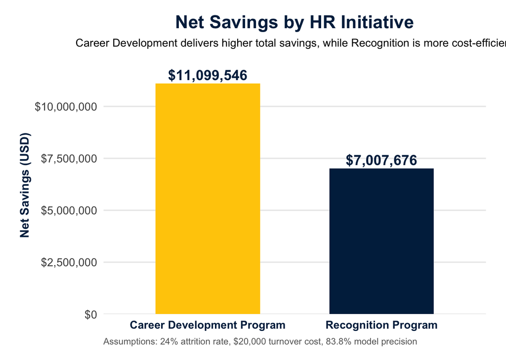

```r
results_plot <- results %>%
  mutate(
    Initiative = factor(
      Initiative,
      levels = c("Career Development Program", "Recognition Program")
    )
  )

ggplot(results_plot, aes(x = Initiative, y = Net_Savings, fill = Initiative)) +
  geom_col(width = 0.6) +
  geom_text(
    aes(label = dollar(Net_Savings, accuracy = 1)),
    vjust = -0.35,
    size = 5,
    fontface = "bold",
    color = "#00274C"
  ) +
  scale_y_continuous(
    labels = dollar_format(),
    expand = expansion(mult = c(0, 0.12))
  ) +
  scale_fill_manual(
    values = c(
      "Career Development Program" = "#FFCB05",
      "Recognition Program" = "#00274C"
    )
  ) +
  labs(
    title = "Net Savings by HR Initiative",
    subtitle = "Career Development delivers higher total savings, while Recognition is more cost-efficient",
    x = NULL,
    y = "Net Savings (USD)",
    caption = "Assumptions: 24% attrition rate, $20,000 turnover cost, 83.8% model precision"
  ) +
  theme_minimal(base_size = 14) +
  theme(
    legend.position = "none",
    panel.grid.minor = element_blank(),
    panel.grid.major.x = element_blank(),
    axis.text.x = element_text(size = 11, face = "bold", color = "#00274C"),
    axis.title.y = element_text(size = 12, face = "bold", color = "#00274C"),
    plot.title = element_text(size = 18, face = "bold", hjust = 0.5, color = "#00274C"),
    plot.subtitle = element_text(size = 11, hjust = 0.5),
    plot.caption = element_text(size = 9, hjust = 0, color = "gray40"),
    plot.margin = margin(15, 20, 15, 20)
  )
```

# 6 Missed and Failed Interventions

Break down remaining turnover costs into two categories:

- missed leavers: employees who left but were not identified by the model
- failed interventions: employees who were identified, received an intervention, but still left  
  ___

Use the attrition rate and model sensitivity to estimate total leavers, identified leavers, and missed leavers.

Then calculate how many identified employees still leave after each intervention.

```r
# Recalculate base values
total_employees <- 14999
attrition_rate <- 0.24
turnover_cost <- 20000
model_sensitivity <- 0.81

total_leavers <- total_employees * attrition_rate
identified_leavers <- total_leavers * model_sensitivity
missed_leavers <- total_leavers - identified_leavers  # false negatives

# Intervention failure (people still left after receiving help)
recog_success <- 0.15
career_success <- 0.25

recog_failed <- identified_leavers * (1 - recog_success)
career_failed <- identified_leavers * (1 - career_success)
```

Convert missed leavers and failed interventions into estimated turnover cost.

```r
# Convert to cost
failures_df <- data.frame(
  Category = c("Missed Leavers",
               "Recognition Program - Failed",
               "Career Development Program - Failed"),
  Cost = round(c(
    missed_leavers * turnover_cost,
    recog_failed * turnover_cost,
    career_failed * turnover_cost
  ), 0)
)



total_leavers <- total_employees * attrition_rate
identified_leavers <- total_leavers * model_sensitivity
missed_leavers <- total_leavers - identified_leavers

recog_success <- 0.15
career_success <- 0.25

recog_failed <- identified_leavers * (1 - recog_success)
career_failed <- identified_leavers * (1 - career_success)

failures_df <- data.frame(
  Category = c("Missed Leavers",
               "Recognition Program - Failed",
               "Career Development Program - Failed"),
  Cost = round(c(
    missed_leavers * turnover_cost,
    recog_failed * turnover_cost,
    career_failed * turnover_cost
  ), 0)
)
```

Plot the estimated cost of missed leavers and failed interventions.

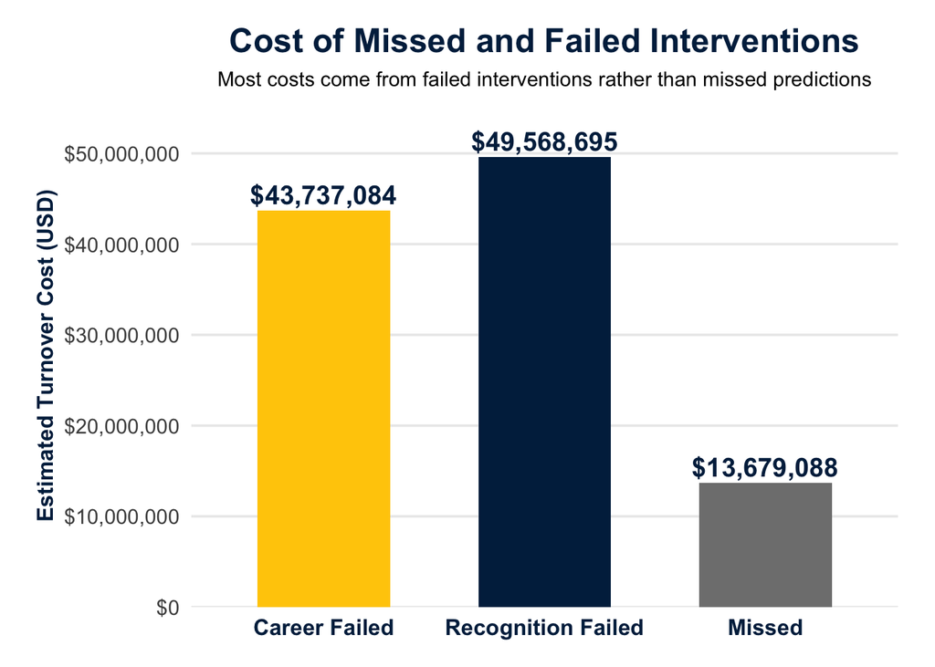

```r
# Create cleaner labels
failures_plot <- failures_df %>%
  mutate(
    Category = c(
      "Missed",
      "Recognition Failed",
      "Career Failed"
    )
  ) %>%
  mutate(
    Category = factor(
      Category,
      levels = c("Career Failed", "Recognition Failed", "Missed")
    )
  )

# Plot
ggplot(failures_plot, aes(x = Category, y = Cost, fill = Category)) +
  geom_col(width = 0.6) +
  geom_text(
    aes(label = dollar(Cost, accuracy = 1)),
    vjust = -0.35,
    size = 5,
    fontface = "bold",
    color = "#00274C"
  ) +
  scale_y_continuous(
    labels = dollar_format(),
    expand = expansion(mult = c(0, 0.12))
  ) +
  scale_fill_manual(
    values = c(
      "Career Failed" = "#FFCB05",       # Maize
      "Recognition Failed" = "#00274C",  # Blue
      "Missed" = "#7F7F7F"               # Gray
    )
  ) +
  labs(
    title = "Cost of Missed and Failed Interventions",
    subtitle = "Most costs come from failed interventions rather than missed predictions",
    x = NULL,
    y = "Estimated Turnover Cost (USD)"
  ) +
  theme_minimal(base_size = 14) +
  theme(
    legend.position = "none",
    panel.grid.minor = element_blank(),
    panel.grid.major.x = element_blank(),
    axis.text.x = element_text(size = 12, face = "bold", color = "#00274C"),
    axis.title.y = element_text(size = 12, face = "bold", color = "#00274C"),
    plot.title = element_text(size = 18, face = "bold", hjust = 0.5, color = "#00274C"),
    plot.subtitle = element_text(size = 11, hjust = 0.5),
    plot.margin = margin(15, 20, 15, 20)
  )
```

Calculate return on investment for each initiative and compare results.

```r
# Calculate ROI
results$ROI <- round((results$Net_Savings / results$Total_Intervention_Cost) * 100, 1)
```

Calculate ROI for each initiative using net savings and total intervention cost.

Plot the results to compare return per dollar spent.

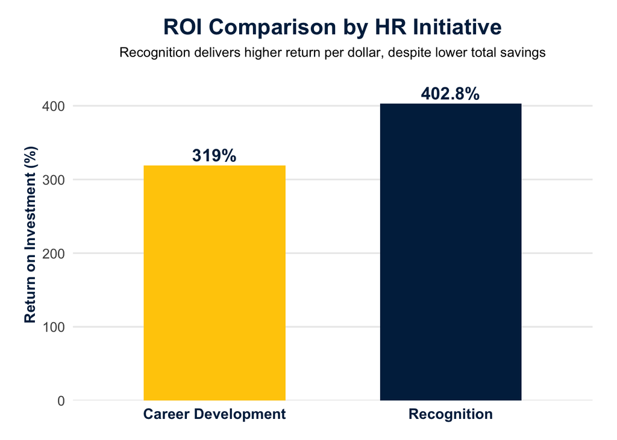

```r
# Clean labels
results_plot <- results %>%
  mutate(
    Initiative = c("Recognition", "Career Development")
  ) %>%
  mutate(
    Initiative = factor(
      Initiative,
      levels = c("Career Development", "Recognition")
    )
  )

# Plot
ggplot(results_plot, aes(x = Initiative, y = ROI, fill = Initiative)) +
  geom_col(width = 0.6) +
  geom_text(
    aes(label = paste0(ROI, "%")),
    vjust = -0.35,
    size = 5,
    fontface = "bold",
    color = "#00274C"
  ) +
  scale_y_continuous(
    expand = expansion(mult = c(0, 0.12))
  ) +
  scale_fill_manual(
    values = c(
      "Career Development" = "#FFCB05",  # Maize
      "Recognition" = "#00274C"          # Blue
    )
  ) +
  labs(
    title = "ROI Comparison by HR Initiative",
    subtitle = "Recognition delivers higher return per dollar, despite lower total savings",
    x = NULL,
    y = "Return on Investment (%)"
  ) +
  theme_minimal(base_size = 14) +
  theme(
    legend.position = "none",
    panel.grid.minor = element_blank(),
    panel.grid.major.x = element_blank(),
    axis.text.x = element_text(size = 12, face = "bold", color = "#00274C"),
    axis.title.y = element_text(size = 12, face = "bold", color = "#00274C"),
    plot.title = element_text(size = 18, face = "bold", hjust = 0.5, color = "#00274C"),
    plot.subtitle = element_text(size = 11, hjust = 0.5),
    plot.margin = margin(15, 20, 15, 20)
  )
```

**Interpretation** Failed interventions account for more cost than missed leavers. Compare these remaining costs before calculating ROI.

ROI Interpretation

Career Development has higher total savings, while Recognition has higher ROI.

Recognition is more efficient per dollar, while Career Development delivers greater total impact.